# Phenology Modelling

Report Exercise

Emma Biland

```r
# Libraries
library(phenocamr);library(terra);library(dplyr);library(here);library(ggplot2);library(GenSA);library(MODISTools);library(geosphere);library(readr);library(tidyr)
```

## Introduction

Plant phenology is tightly controlled by temperature, radiation and winter dormancy processes. Under current climate warming, the timing of leaf emergence, flowering and senescence is shifting across many ecosystems, with consequences for carbon uptake, species interactions and ecosystem functioning (Morisette et al., 2009; Richardson et al., 2013). Phenological indicators are therefore widely used to assess ecological responses to climate variability and change.

This exercise follows Chapter 6 of [“Handful of Pixels” chapter 6](https://geco-bern.github.io/handfull_of_pixels/phenology_modelling.html) and focuses on modelling spring leaf-out at the Harvard Forest PhenoCam site using temperature-based growing degree days (GDD). Temperature and phenology observations were downloaded using the [{phenocamr}](https://bluegreen-labs.github.io/phenocamr/) [R package](https://bluegreen-labs.github.io/phenocamr/), and a baseline GDD model was calibrated against PhenoCam-derived transition dates. We then explored how model structure could be improved and implemented one alternative formulation. Finally, we compared our model predictions with the MODIS MCD12Q2 phenology product to assess consistency between ground-based and satellite-derived phenology at regional scale.

##### **Data download and preprocessing (Harvard PhenoCam + DAYMET)**

```r
# Loading and processing data from harvard
download_phenocam(
  site = "harvard$",
  veg_type = "DB",
  roi_id = "1000",
  daymet = TRUE,
  phenophase = TRUE,
  trim = 2022,
  out_dir = tempdir())

harvard_phenocam_data <- read_csv(
  file.path(tempdir(), "harvard_DB_1000_3day.csv"),
  comment = "#")

harvard_phenology <- read_csv(
  file.path(
    tempdir(),
    "harvard_DB_1000_3day_transition_dates.csv"
  ),
  comment = "#"
) |>
  filter(
    direction == "rising",
    gcc_value == "gcc_90"
  )

# return mean daily temperature as well
# as formal dates (for plotting)
harvard_temp <- harvard_phenocam_data |>
  group_by(year) |>
  mutate(
    tmean = (tmax..deg.c. + tmin..deg.c.)/2
  ) |>
  mutate(
    date = as.Date(date),
    gdd = cumsum(ifelse(tmean >= 5, tmean - 5, 0))
  ) |>
  select(
    date,
    year,
    tmean,
    gdd
  ) |>
  ungroup()

# Determination of the photoperiod which will be used later
# Coordinates for Harvard Forest (approx.)
harvard_lat <- 42.5378
harvard_lon <- -72.1715

harvard_temp <- harvard_temp |>
  mutate(
    doy = as.numeric(format(date, "%j")),
    photoperiod = daylength(
      lat = harvard_lat * pi/180,
      doy = doy
    )   # déjà en heures
  )


# convert the harvard phenology data and only
# retain required data
harvard_phenology <- harvard_phenology |>
  mutate(
    doy = as.numeric(format(as.Date(transition_25),"%j")),
    year = as.numeric(format(as.Date(transition_25),"%Y"))
  ) |>
  select(
    year,
    doy,
    transition_25,
    threshold_25
    )
```

```r
source(here("functions","phenology_algo.R"))
```

##### **Baseline GDD model**

```r
# starting model parameters
par = c(0, 130)

# limits to the parameter space
lower <- c(-10,0)
upper <- c(45,500)

# data needs to be provided in a consistent
# single data file, a nested data structure
# will therefore accept non standard data formats
data <- list(
  drivers = harvard_temp,
  validation = harvard_phenology
  )

# optimize the model parameters
optim_par = GenSA(
 par = par,
 fn = rmse_gdd,
 lower = lower,
 upper = upper,
 control = list(
   max.call = 4000
   ),
 data = data
)$par

# run the model for all years
# to get the phenology predictions
predictions <- harvard_temp |>
  group_by(year) |>
  summarize(
   prediction = gdd_model(
    temp = tmean,
    par = optim_par
  )
  )
print(predictions)
```

```
## # A tibble: 16 × 2
##     year prediction
##    <dbl>      <int>
##  1  2008        128
##  2  2009        125
##  3  2010        119
##  4  2011        131
##  5  2012        115
##  6  2013        130
##  7  2014        135
##  8  2015        131
##  9  2016        128
## 10  2017        124
## 11  2018        130
## 12  2019        128
## 13  2020        137
## 14  2021        122
## 15  2022        129
## 16  2023         NA
```

The modelled day of leaf unfolding (DOY) compared with the observed values is shown below:

[figure not shown]

```r
model_lm <- lm(prediction ~ doy, data = validation)
summary(model_lm)
```

```
##
## Call:
## lm(formula = prediction ~ doy, data = validation)
##
## Residuals:
##     Min      1Q  Median      3Q     Max
## -7.6429 -2.4753  0.8327  3.3814  5.1193
##
## Coefficients:
##             Estimate Std. Error t value Pr(>|t|)
## (Intercept)  33.1303    28.2097   1.174  0.26129
## doy           0.7459     0.2229   3.347  0.00525 **
## ---
## Signif. codes:  0 '***' 0.001 '**' 0.01 '*' 0.05 '.' 0.1 ' ' 1
##
## Residual standard error: 4.377 on 13 degrees of freedom
##   (1 observation effacée parce que manquante)
## Multiple R-squared:  0.4628, Adjusted R-squared:  0.4215
## F-statistic:  11.2 on 1 and 13 DF,  p-value: 0.005253
```

The simple GDD model provides a reasonable approximation of the observed PhenoCam leaf-out dates, yet several weaknesses remain evident. The regression between observed DOY and model predictions yields:

- slope = 0.75, indicating a substantial underestimation of interannual variability;
- intercept = 33.1 (non-significant);
- R² = 0.46, meaning that less than half of the variance is explained;
- RMSE ≈ 4.4 days.

The model tends to predict early years too late and late years too early. This behaviour is consistent with the limitations of linear GDD models, which lack sensitivity to winter conditions and assume uniform temperature effectiveness throughout spring.

## Exercise

### 1. Model optimization

#### Model improvements

**(1) Include a chilling requirement before heat accumulation**  
Deciduous broadleaf species require winter chilling to break dormancy and become responsive to spring warming. Years with insufficient chilling accumulate GDD earlier but do not necessarily produce an earlier phenological response. Adding a chilling phase helps reduce early predictions in exceptionally warm winters.

**(2) Use a non-linear temperature response**  
The linear GDD formulation assumes that all heat above the threshold contributes equally to leaf development. In reality, heat accumulation saturates at high temperatures and becomes inefficient at low temperatures. Non-linear functions, such as triangular or sigmoid responses, reduce unrealistically early or late predictions.

**(3) triangular temperature response model**  
The triangular temperature response model assumes that temperature contributes to plant development only within a biologically meaningful range. Forcing increases linearly from a minimum temperature (Tmin) to an optimum (Topt), and then declines toward a maximum temperature (Tmax), reflecting how growth efficiency peaks at intermediate conditions. This non-linear formulation aims to represent physiological temperature responses more realistically than the simple linear GDD model.

In this exercise, we implemented the **triangular temperature response model** and compared its behaviour with the baseline GDD formulation.

### 2. Implementation of optimization

```r
# data list for optimisation (same structure)
data_tri <- list(
  drivers    = harvard_temp,
  validation = harvard_phenology
)

# par = c(Tmin, Topt, Tmax, Hcrit)
par0_tri   <- c(0, 15, 30, 80)    # point de départ plausible
lower_tri  <- c(-5,  5, 20, 10)   # bornes minimales
upper_tri  <- c(10, 25, 40, 300)  # bornes maximales

optim_tri <- optim(
  par     = par0_tri,
  fn      = rmse_gdd_tri,
  data    = data_tri,
  method  = "L-BFGS-B",
  lower   = lower_tri,
  upper   = upper_tri,
  control = list(maxit = 300)
)

optim_par_tri <- optim_tri$par
optim_par_tri
```

```
## [1]  0 15 30 80
```

```r
# Annual predictions with triangular model
predictions_tri <- harvard_temp |>
  dplyr::group_by(year) |>
  dplyr::summarise(
    prediction_tri = gdd_tri_model(
      temp = tmean,
      par  = optim_par_tri
    )
  )

validation_tri <- dplyr::left_join(predictions_tri, harvard_phenology)

# Regression
lm_tri <- lm(prediction_tri ~ doy, data = validation_tri)
summary(lm_tri)
```

```
##
## Call:
## lm(formula = prediction_tri ~ doy, data = validation_tri)
##
## Residuals:
##     Min      1Q  Median      3Q     Max
## -8.8310 -5.9839 -0.1486  5.6867 10.5043
##
## Coefficients:
##             Estimate Std. Error t value Pr(>|t|)
## (Intercept) 122.7366    45.0032   2.727   0.0173 *
## doy           0.6647     0.3556   1.869   0.0843 .
## ---
## Signif. codes:  0 '***' 0.001 '**' 0.01 '*' 0.05 '.' 0.1 ' ' 1
##
## Residual standard error: 6.983 on 13 degrees of freedom
##   (1 observation effacée parce que manquante)
## Multiple R-squared:  0.2119, Adjusted R-squared:  0.1512
## F-statistic: 3.495 on 1 and 13 DF,  p-value: 0.08425
```

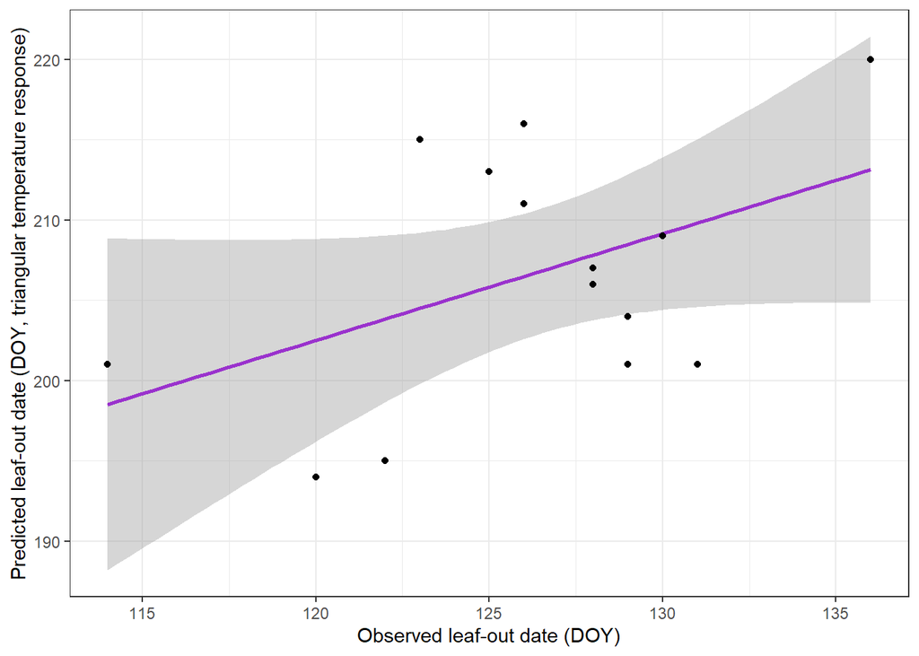

```r
ggplot(validation_tri) +
  geom_smooth(
    aes(
      doy,
      prediction_tri
    ),
    colour = "darkorchid3",
    method = "lm"
  ) +
  geom_point(
    aes(
      doy,
      prediction_tri
      )
  ) +
  geom_abline(
    intercept=0,
    slope=1,
    linetype="dotted"
  ) +
  labs(
    x = "Observed leaf-out date (DOY)",
    y = "Predicted leaf-out date (DOY, triangular temperature response)"
  ) +
  theme_bw() +
  theme(
    legend.position = "none"
  )
```

**Triangular temperature-response model**

The triangular GDD model assumes that thermal forcing increases linearly from a minimum temperature to an optimum, and declines at higher temperatures. This structure follows biological evidence that growth rates peak at intermediate temperatures (Chuine, 2000).